# Targeting a Housing Subsidy

Akira Di Sandro

2023-11-03

## Introduction

The Department of Housing and Community Development (HCD) of Emil City runs a home repair tax credit program every year which a subset of home owners qualify for. About 25% of the people who enroll in the program end up taking the tax credit ($5,000) and see an average premium of $10,000 as a result of the home repairs done using the credit. In addition, the homes surrounding the repaired home see an aggregate premium of $56,000.

### Motivation

Up until this point, the HCD has been advertising this program to home owners that qualify in a random manner, but this is an inefficient use of resources. Each person that enrolls in this program costs the HCD an average of $2850 for marketing and counselling costs. From prior data exploration, we’ve seen that certain characteristics of home owners, how and when they were contacted, and other economic variables correlate. We believe that we can build a model to predict which owners are most likely to enter the program and take the tax credit, allowing the HCD to advertise the program more effectively and ultimately saving some costs.

In this document, we present a model that we believe could help the HCD spend their money more efficiently.

```r
subsidy <- read_csv("/Users/akidi/Documents/MUSA5080/Assignments/HW05/housingSubsidy.csv") %>% dplyr::select(-1)
```

## Methods

### Data Exploration

The first step is always to look at what our data looks like and understand how the features relate with program enrollment. This gives us an idea of which features have the most influence on whether someone decides to enroll in the program or not, along with what kind of features we can create from the data we have to improve our prediction model.

### Goodness of Fit and Cross Validation

We split the data into a training and testing set and train our model with the training set (65% of data). Using the prediction model, we predict the program enrollment status of the people in the testing set. We use various goodness of fit metrics including the McFadden R-squared value, sensitivity, specificity, and a Receiver Operating Characteristic (ROC) Curve to assess our model’s ability to accurately predict program enrollment.

Using k-fold cross validation with 100 folds, we test the generalizability of the model. More specifically, we assess the generalizability by looking at the distributions of the measures, Area Under the Curve AUC (labeled as ROC) which is another goodness of fit metric, sensitivity, and specificity. Ideally, we have distributions that are close to the mean, which would mean our model generalizes to many subsets of data pretty consistently.

If we have poor goodness of fit metrics and/or cross validation we go back to the drawing board and test new models until we have one that is satisfactory.

## Results

### Understanding the Data

We first explore the data, specifically how the various features are related to program enrollment.

In figure 1, we see that the correlation between this subset of features (continuous) and program enrollment is generally weak (ranging from 0.05 to 0.35 for the absolute value of the correlation coefficient). The points at the top (y = 1) mean that those people did enroll in the program, while the points below (y = 0) means that they did NOT enroll. In the middle of the figure, we see that as people are less likely to enroll in the program the higher the inflation rate is. This makes sens because the $5000 credit can buy more things when the inflation rate is low, making the program look more attractive.

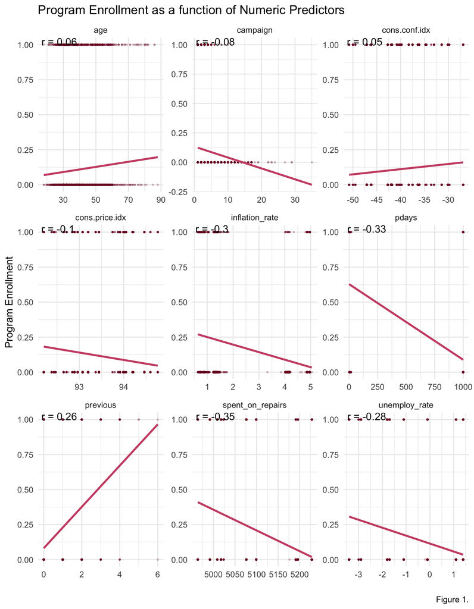

```r
# numeric variables as scatters
num_vars <- subsidy %>% dplyr::select_if(is.numeric)

correlation.cor <- num_vars %>%
  gather(Variable, Value, -y_numeric) %>%
  group_by(Variable) %>%
  summarize(correlation = cor(Value, y_numeric, use = "complete.obs"))

num_vars %>% gather(Variable, Value, -y_numeric) %>%
  ggplot(aes(Value, y_numeric)) +
  geom_point(size = .5, alpha = 0.2, color = mypalette1[2]) +
  geom_smooth(method = "lm", se=F, color = mypalette1[1]) +
  geom_text(data = correlation.cor, aes(label = paste("r =", round(correlation, 2))),
            x=-Inf, y=Inf, vjust = 1, hjust = -.1) +
  facet_wrap(~Variable, ncol = 3, scales = "free") +
  labs(title = "Program Enrollment as a function of Numeric Predictors",
       y = "Program Enrollment", x = "",
       caption = "Figure 1.") +
  theme_minimal()
```

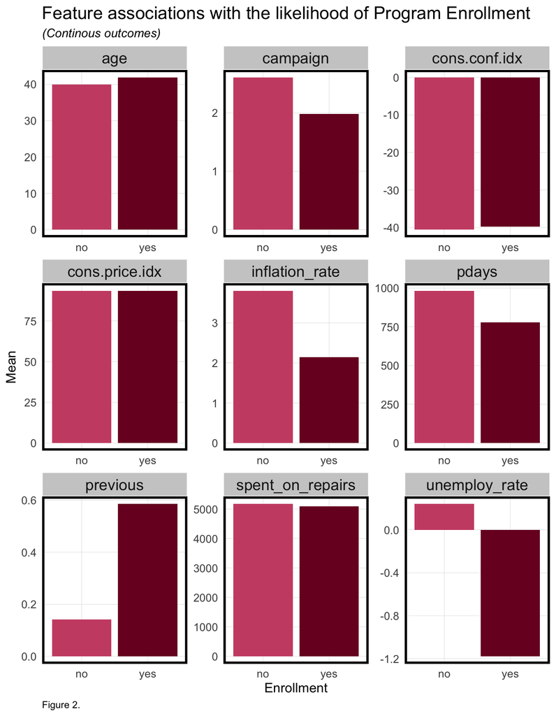

```r
subsidy %>%
  dplyr::select(y,age,campaign:previous,unemploy_rate:spent_on_repairs) %>%
  mutate(age = as.numeric(age),
         campaign = as.numeric(campaign),
         pdays = as.numeric(pdays),
         previous = as.numeric(previous),
         unemploy_rate =as.numeric(unemploy_rate),
         cons.price.idx = as.numeric(cons.price.idx),
         cons.conf.idx = as.numeric(cons.conf.idx),
         inflation_rate = as.numeric(inflation_rate),
         spent_on_repairs = as.numeric(spent_on_repairs)) %>%
  gather(Variable, value, -y) %>%
  ggplot(aes(y, value, fill=y)) +
    geom_bar(position = "dodge", stat = "summary", fun = "mean") +
    facet_wrap(~Variable, scales = "free") +
    scale_fill_manual(values = mypalette1) +
    labs(x="Enrollment", y="Mean",
         title = "Feature associations with the likelihood of Program Enrollment",
         subtitle = "(Continous outcomes)",
         caption = "Figure 2.") +
    plotTheme() + theme(legend.position = "none")
```

Yet another way to visualize these features is by plotting frequency polygons like in figure 3. These plots help us see the distribution of values for each feature, separated by whether they enrolled or not. This figure shows us that for a variable like pdays, most of the people who did not enroll in the program were contacted 1,000 days after their last contact but we see that most of the people who enrolled were also contacted 1,000 days after their last contact. The difference in means we saw in figure 2 for this variable comes from the fact that there are just more people who didn’t end up enrolling in the program.

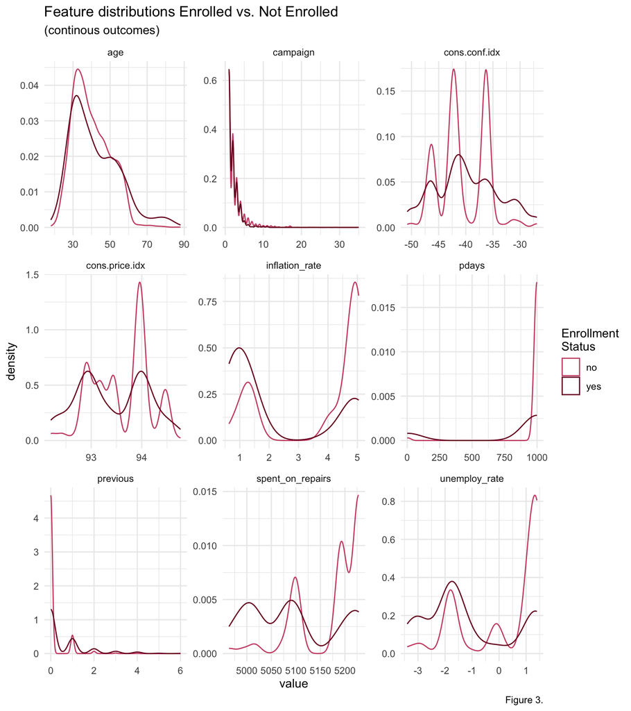

```r
subsidy %>%
    dplyr::select(y,age,campaign:previous,unemploy_rate:spent_on_repairs) %>%
    mutate(age = as.numeric(age),
           campaign = as.numeric(campaign),
           pdays = as.numeric(pdays),
           previous = as.numeric(previous),
           unemploy_rate =as.numeric(unemploy_rate),
           cons.price.idx = as.numeric(cons.price.idx),
           cons.conf.idx = as.numeric(cons.conf.idx),
           inflation_rate = as.numeric(inflation_rate),
           spent_on_repairs = as.numeric(spent_on_repairs)) %>%
    gather(Variable, value, -y) %>%
    ggplot() +
    geom_density(aes(value, color=y), fill = "transparent") +
    facet_wrap(~Variable, scales = "free", ncol = 3) +
    scale_color_manual(values = mypalette1) +
    labs(title = "Feature distributions Enrolled vs. Not Enrolled",
         subtitle = "(continous outcomes)",
         caption = "Figure 3.", fill = "", color = "Enrollment\nStatus") +
  theme_minimal()
```

The relationship between categorical variables and enrollment status are shown in figure 4. As previously discussed, there are many more people who did not enroll, so we see that the “no” bars are always much taller (aka more counts of that value) for almost all values in almost all variables. A notable feature here is poutcome (outcome of the previous marketing campaign), where the people who were successfully convinced to enroll in the previous campaign were more likely to enroll in the current campaign. Another interesting variable is contact (method of contact) where the proportion of people who were contacted on their cellphones is higher in the group of people who enrolled in our current campaign.

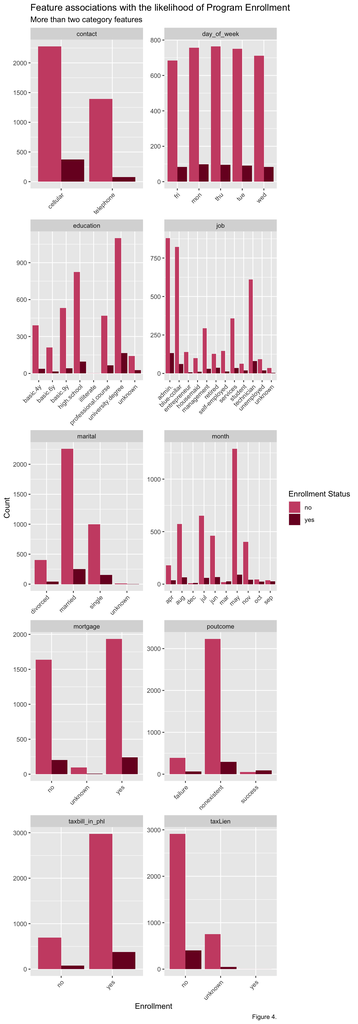

```r
# categorical variables
subsidy %>%
    dplyr::select(y,job:day_of_week,poutcome) %>%
    gather(Variable, value, -y) %>%
    count(Variable, value, y) %>%
      ggplot(., aes(value, n, fill = y)) +
        geom_bar(position = "dodge", stat="identity") +
        facet_wrap(~Variable, scales="free",ncol=2) +
        scale_fill_manual(values = mypalette1) +
        labs(x="Enrollment", y="Count",
           title = "Feature associations with the likelihood of Program Enrollment",
           subtitle = "More than two category features",
           fill = "Enrollment Status",
           caption = "Figure 4.") +
        theme(axis.text.x = element_text(angle = 45, hjust = 1))
```

```r
# trying to scale these to see real differences

# subsidy %>% group_by(y) %>% summarise(n=n())
# no: 3668
# yes: 451

# subsidy %>%
#     dplyr::select(y,job:day_of_week,poutcome) %>%
#     gather(Variable, value, -y) %>%
#     count(Variable, value, y) %>%
#     mutate(n_pct = ifelse(y == "no", n/3668, n/451)) %>%
#       ggplot(., aes(value, n_pct, fill = y)) +
#         geom_bar(position = "dodge", stat="identity") +
#         facet_wrap(~Variable, scales="free",ncol=2) +
#         scale_fill_manual(values = mypalette1) +
#         labs(x="Enrollment", y="Count",
#            title = "Feature associations with the likelihood of Program Enrollment",
#            subtitle = "More than two category features",
#            fill = "Enrollment Status",
#            caption = "Figure 4try.") +
#         theme(axis.text.x = element_text(angle = 45, hjust = 1))
```

### Prediction Model

For the following sections we present the Kitchen Sink model (a model with all data available used as predictors of outcome) side by side with our new prediction model to discuss the validity and efficiency of the latter model.

The Kitchen Sink model gives us an idea of which predictors are significant, or have a strong influence on whether a person enrolls in the program or not. From this information, we engineered some new features to include in a new and improved model. After defining and testing combinations of several new features, the best set of new features were (1) a binary variable describing whether the inflation rate was over 3 or not (1 and 0, respectively); (2) a 3-level categorical variable describing how much the homeowner spent on home repairs (repair costs < $5,075 = “low”, repair costs >= $5,075 and < $5,175 = “mid”, repair costs >= $5,175 = “high”); (3) a 3-level categorical variable describing the unemployment rate (unemployment rate < -2 = “very_negative”, unemployment rate >= -2 and < 0 = “negative”, unemployment rate >= 0 = “positive”); and (4) a binary variable describing whether pdays (number of days after individual was last contacted from a previous program) was > 250 or not (1 and 0, respectively).

Figure 5 summarizes these features’ relationships to program enrollment using counts. One notable relationship we can observe from this figure is that homeowners who spend the least amount on home repairs tend to enroll in the program more. Perhaps this can be explained by the fact that people who spend less money on home repairs tend to be thrifty and cost-efficient with their home improvements so they see the tax credit program as being veery attractive (another way to save money while improving the quality of their home).

```r
trainIndex <- createDataPartition(paste(subsidy$y,subsidy$taxLien), p = .65,
                                  list = FALSE,
                                  times = 1)
kitchTrain <- subsidy[ trainIndex,]
kitchTest  <- subsidy[-trainIndex,]
```

```r
# define kitchen sink model
kitchreg <- glm(y_numeric ~ .,
                data=kitchTrain %>% dplyr::select(-y),
                family="binomial" (link="logit"))

kitch_sum <- summary(kitchreg)

# for mcfadden
kitch_mcf <- pR2(kitchreg)[4] # 0.2123023

# names of variables + kitchen sink model column for summary table
kitch_col <- kitch_sum$coefficients %>% as.data.frame() %>%
  mutate(var_names = row.names(.),
         rounded_est = round(Estimate,3),
         SE = round(`Std. Error`,3),
         sig_stars = case_when(`Pr(>|z|)` < .001 ~ "***",
                               `Pr(>|z|)` < .01 ~ "**",
                               `Pr(>|z|)` < .05 ~ "*",
                               .default = ""),
         kitch_reg = paste0(rounded_est,sig_stars," (",SE,")")) %>%
  dplyr::select(var_names,kitch_reg)

# remove rownames
row.names(kitch_col) <- NULL
```

```r
# hoping that this helps me decide which features to drop
# for_cormat <- subsidy %>%
#   dplyr::select(-c(job:day_of_week,poutcome,y))
#
# ggcorrplot(
#   round(cor(for_cormat), 1),
#   # method = "circle",
#   p.mat = cor_pmat(for_cormat),
#   colors = c("#4b2875", "white", "#9c1339"),
#   type="lower",
#   insig = "blank",
#   digits = 4,
#   lab = T, lab_size = 2) +
#     labs(title = "Correlation",
#          caption = "Figure 3.")

# unemploy and inflation rate are 100% correlated, only need one
```

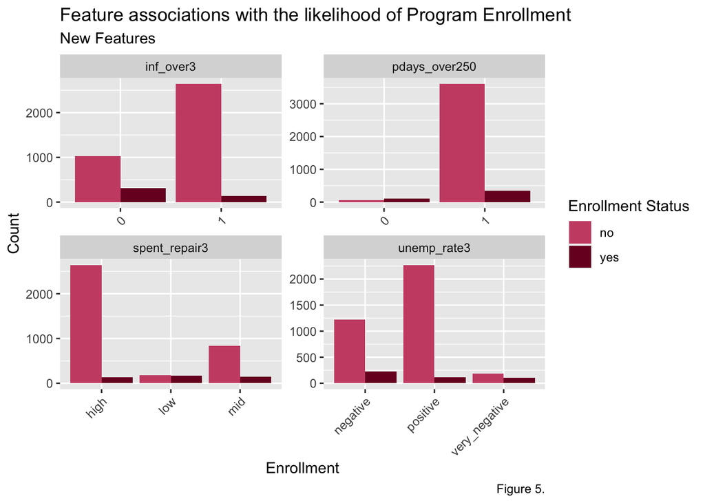

```r
# ideas for features to engineer: spent_on_repairs (above or under $5000), pdays (more or less than 500 days),
# inflation_rate > 3 or not, unemploy_rate > -1 or not

# subsidy_new <- subsidy %>%
#   mutate(
#     # poutcome_success = ifelse(poutcome == "success", 1, 0), # previous campaign successful or not
#          inf_over3 = ifelse(inflation_rate >= 3, 1, 0), # inflation_rate is over 3 or not
#          # spent_over5k = ifelse(spent_on_repairs >= 5000,1,0), # spent over $5k in repairs or not
#          spent_repair3 = case_when(spent_on_repairs < 5075 ~ "low",
#                                    spent_on_repairs < 5175 ~ "mid",
#                                    .default = "high"), # spent over $5k in repairs or not
#          # cci_over_n35 = ifelse(cons.conf.idx > -35, 1, 0),
#          unemp_rate3 = case_when(unemploy_rate < -2 ~ "very_negative",
#                                  unemploy_rate < 0 ~ "negative",
#                                  .default = "positive",
         # conf.price = cons.conf.idx/cons.price.idx
#          ) %>%
#   # dplyr::select(-c(poutcome,inflation_rate,spent_on_repairs,unemploy_rate)) # ,cons.conf.idx
#   dplyr::select(-c(inflation_rate,spent_on_repairs,unemploy_rate))

subsidy_new <- subsidy %>%
  mutate(inf_over3 = ifelse(inflation_rate >= 3, 1, 0),
         spent_repair3 = case_when(spent_on_repairs < 5075 ~ "low",
                                   spent_on_repairs < 5175 ~ "mid",
                                   .default = "high"),
         unemp_rate3 = case_when(unemploy_rate < -2 ~ "very_negative",
                                 unemploy_rate < 0 ~ "negative",
                                 .default = "positive"),
         pdays_over250 = ifelse(pdays > 250,1,0))

# visualize new features
subsidy_new %>%
    dplyr::select(y,inf_over3,spent_repair3,unemp_rate3,pdays_over250) %>%
    gather(Variable, value, -y) %>%
    count(Variable, value, y) %>%
      ggplot(., aes(value, n, fill = y)) +
        geom_bar(position = "dodge", stat="identity") +
        facet_wrap(~Variable, scales="free",ncol=2) +
        scale_fill_manual(values = mypalette1) +
        labs(x="Enrollment", y="Count",
           title = "Feature associations with the likelihood of Program Enrollment",
           subtitle = "New Features",
           fill = "Enrollment Status",
           caption = "Figure 5.") +
        theme(axis.text.x = element_text(angle = 45, hjust = 1))
```

```r
# split data into training and testing set again
enrollTrain <- subsidy_new[ trainIndex,]
enrollTest  <- subsidy_new[-trainIndex,]
```

```r
enrollreg <- glm(y_numeric ~ .,
                  data=enrollTrain %>% dplyr::select(-c(y,inflation_rate,spent_on_repairs,unemploy_rate,pdays)),
                  family="binomial" (link="logit"))

enroll_sum <- summary(enrollreg)

# for mcfadden
enroll_mcf <- pR2(enrollreg)[4] # 0.2125163

# names of variables + kitchen sink model column for summary table
enroll_col <- enroll_sum$coefficients %>% as.data.frame() %>%
  mutate(var_names = row.names(.),
         rounded_est = round(Estimate,3),
         SE = round(`Std. Error`,3),
         sig_stars = case_when(`Pr(>|z|)` < .001 ~ "***",
                               `Pr(>|z|)` < .01 ~ "**",
                               `Pr(>|z|)` < .05 ~ "*",
                               .default = ""),
         enroll_reg = paste0(rounded_est,sig_stars," (",SE,")")) %>%
  dplyr::select(var_names,enroll_reg)

# remove rownames
row.names(enroll_col) <- NULL
```

```r
testProbs <- data.frame(Outcome = as.factor(enrollTest$y_numeric),
                        Probs = predict(enrollreg, enrollTest, type= "response"))

# plotting predicted by observed outcome
# ggplot(testProbs, aes(x = Probs, fill = as.factor(Outcome))) +
#   geom_density() +
#   facet_grid(Outcome ~ .) +
#   scale_fill_manual(values = mypalette1) + xlim(0, 1) +
#   labs(x = "Program Enrollment", y = "Density of probabilities",
#        title = "Distribution of predicted probabilities by observed outcome") +
#   plotTheme() + theme(strip.text.x = element_text(size = 18),
#         legend.position = "none")

# set threshold
testProbs <-
  testProbs %>%
  mutate(predOutcome  = as.factor(ifelse(testProbs$Probs > 0.5 , 1, 0)))
```

The table below (table 1) presents a regression summary for both the kitchen sink and new models. Some predictors have a strong influence on program enrollment across both models including age, campaign, cons.price.idx (consumer price index), contact (method used to contact homeowner), months of March and November, and unemployment rate. Though we replaced some variables with their engineered counterparts, the predictive power for all of the features are similar across both models.

```r
options(knitr.kable.NA = "")
# combine kitch_col and enroll_col from above
full_join(kitch_col,enroll_col,by="var_names") %>%
  arrange(var_names) %>%
  kbl(caption = "Table 1: Summary of Kitchen Sink and New Prediction Models",
      col.names = c("Predictor", "Kitchen Sink", "New Model")) %>%
  kable_styling("striped", full_width = F) %>%
  kable_classic(full_width = F, html_font = "Cambria") %>%
  add_footnote(paste0("The McFadden Scores were ",round(kitch_mcf,5),
                      " and ", round(enroll_mcf,5), " for the kitchen sink model and new model, respectively."))
```

Table 1: Summary of Kitchen Sink and New Prediction Models

| Predictor | Kitchen Sink | New Model |
| --- | --- | --- |
| (Intercept) | -251.127 (135.488) | -113.962** (34.734) |
| age | 0.019* (0.009) | 0.018* (0.009) |
| campaign | -0.103* (0.046) | -0.1* (0.046) |
| cons.conf.idx | 0.031 (0.029) | -0.03 (0.051) |
| cons.price.idx | 2.323** (0.893) | 1.188** (0.385) |
| contacttelephone | -1.163*** (0.312) | -0.968** (0.298) |
| day_of_weekmon | 0.164 (0.239) | 0.15 (0.238) |
| day_of_weekthu | 0.048 (0.239) | 0.01 (0.239) |
| day_of_weektue | 0.248 (0.239) | 0.23 (0.239) |
| day_of_weekwed | 0.357 (0.241) | 0.33 (0.24) |
| educationbasic.6y | 0.28 (0.402) | 0.269 (0.402) |
| educationbasic.9y | 0.117 (0.332) | 0.105 (0.331) |
| educationhigh.school | -0.102 (0.329) | -0.144 (0.329) |
| educationilliterate | -11.921 (535.411) | -12.128 (535.412) |
| educationprofessional.course | 0.1 (0.349) | 0.055 (0.35) |
| educationuniversity.degree | -0.102 (0.33) | -0.137 (0.331) |
| educationunknown | 0.004 (0.436) | -0.029 (0.437) |
| inf_over3 |  | 0.938 (0.971) |
| inflation_rate | 0.385 (0.46) |  |
| jobblue-collar | -0.377 (0.283) | -0.358 (0.282) |
| jobentrepreneur | -0.521 (0.511) | -0.512 (0.512) |
| jobhousemaid | 0.201 (0.476) | 0.147 (0.481) |
| jobmanagement | -0.51 (0.327) | -0.502 (0.327) |
| jobretired | -0.12 (0.383) | -0.114 (0.382) |
| jobself-employed | -0.453 (0.44) | -0.488 (0.441) |
| jobservices | -0.286 (0.313) | -0.276 (0.314) |
| jobstudent | -0.237 (0.46) | -0.21 (0.457) |
| jobtechnician | 0.128 (0.234) | 0.142 (0.235) |
| jobunemployed | 0.106 (0.43) | 0.073 (0.434) |
| jobunknown | -0.532 (0.791) | -0.488 (0.792) |
| maritalmarried | 0.227 (0.258) | 0.198 (0.257) |
| maritalsingle | 0.421 (0.292) | 0.416 (0.291) |
| maritalunknown | 0.242 (1.214) | 0.199 (1.226) |
| monthaug | 0.262 (0.447) | -0.504 (0.393) |
| monthdec | 1.907* (0.829) | 0.083 (1.031) |
| monthjul | -0.207 (0.378) | -0.842 (0.478) |
| monthjun | -0.318 (0.47) | -0.65 (0.491) |
| monthmar | 2.17*** (0.598) | 1.713** (0.547) |
| monthmay | -0.08 (0.304) | -0.247 (0.285) |
| monthnov | -0.909* (0.445) | -2.288** (0.761) |
| monthoct | -0.06 (0.55) | -1.289 (0.672) |
| monthsep | 0.342 (0.636) | -0.974 (0.552) |
| mortgageunknown | -0.397 (0.548) | -0.427 (0.554) |
| mortgageyes | 0.012 (0.149) | 0.018 (0.149) |
| pdays | -0.001 (0.001) |  |
| pdays_over250 |  | -0.822 (0.648) |
| poutcomenonexistent | 0.429 (0.329) | 0.421 (0.329) |
| poutcomesuccess | 1.063 (0.652) | 1.062 (0.656) |
| previous | 0.073 (0.193) | 0.06 (0.191) |
| spent_on_repairs | 0.006 (0.011) |  |
| spent_repair3low |  | 1.106 (0.749) |
| taxLienunknown | -0.132 (0.224) | -0.108 (0.225) |
| taxLienyes | -10.142 (535.411) | -10.181 (535.411) |
| taxbill_in_phlyes | -0.063 (0.198) | -0.072 (0.199) |
| unemp_rate3positive |  | -1.965** (0.649) |
| unemp_rate3very_negative |  | 2.386** (0.728) |
| unemploy_rate | -1.605** (0.504) |  |

<sup>a</sup> The McFadden Scores were 0.24332 and 0.24419 for the kitchen sink model and new model, respectively.

### Cross Validation

We performed a 100-fold cross validation for both the Kitchen Sink and New models. Figure 6 below summarizes the results of this cross validation by presenting the distribution of goodness-of-fit measures, specifically AUC, sensitivity (Sens), and specificity (Spec). According to these measures, the new model performs very similarly to the kitchen sink model. The distribution of these measures remains consistent across the two models, but the mean sensitivity and specificity values are slightly higher for the new model with a mean specificity of 0.980 and 0.981 as well as a mean sensitivity of 0.223 and 0.224 for the kitchen sink and new model respectively.

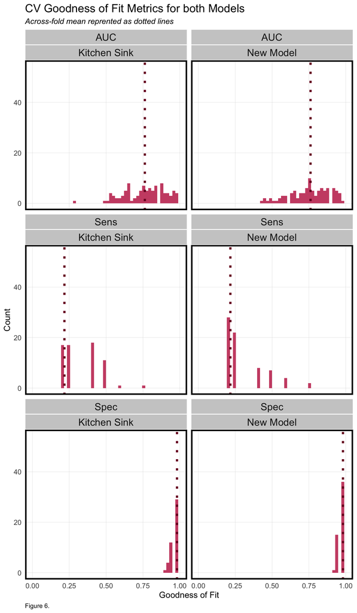

```r
ctrl <- trainControl(method = "cv", number = 100, classProbs=TRUE, summaryFunction=twoClassSummary)

kitchcvFit <- train(y ~ ., data = subsidy %>%
                                  dplyr::select(
                                   -c(y_numeric)),
                method="glm", family="binomial",
                metric="ROC", trControl = ctrl)

kitchcvFit

modcvFit2 <- train(y ~ ., data = subsidy_new %>%
                                  dplyr::select(-y_numeric,inflation_rate,spent_on_repairs,unemploy_rate,pdays),
                method="glm", family="binomial",
                metric="ROC", trControl = ctrl)

modcvFit2

# visualize distribution of goodness of fit metrics
rbind(dplyr::select(kitchcvFit$resample, -Resample) %>%
        gather(metric, value) %>%
        left_join(gather(kitchcvFit$results[2:4], metric, mean)) %>% mutate(model = "Kitchen Sink",
                                                                            metric = case_when(metric == "Sens" ~ "Spec",
                                                                                               metric == "Spec" ~ "Sens",
                                                                                               .default = "AUC")),
      dplyr::select(modcvFit2$resample, -Resample) %>%
        gather(metric, value) %>%
        left_join(gather(modcvFit2$results[2:4], metric, mean)) %>% mutate(model = "New Model",
                                                                           metric = case_when(metric == "Sens" ~ "Spec",
                                                                                              metric == "Spec" ~ "Sens",
                                                                                              .default = "AUC"))) %>%
  ggplot(aes(value)) +
    geom_histogram(bins=50, fill = "#cc5073") +
    facet_wrap(vars(metric,model),ncol = 2) +
    geom_vline(aes(xintercept = mean), colour = "#7a0728", linetype = 3, size = 1.5) +
    scale_x_continuous(limits = c(0, 1)) +
    labs(x="Goodness of Fit", y="Count", title="CV Goodness of Fit Metrics for both Models",
         subtitle = "Across-fold mean reprented as dotted lines",
         caption = "Figure 6.") +
    plotTheme()
```

### ROC Curve

We use a ROC curve to visualize the trade-off of TP and FP, two very important confusion metrics. The grey line in figure 7 represents the ratio of TP and FP for a model that performs as well as a coin-flip, being right 50% of the time and wrong the other 50% of the time. Our model’s TP/FP tradeoff is shown by the maroon-colored curve. Our model has an area under the curve (AUC) of 0.7976, which is a reasonable value for this goodness-of-fit metric.

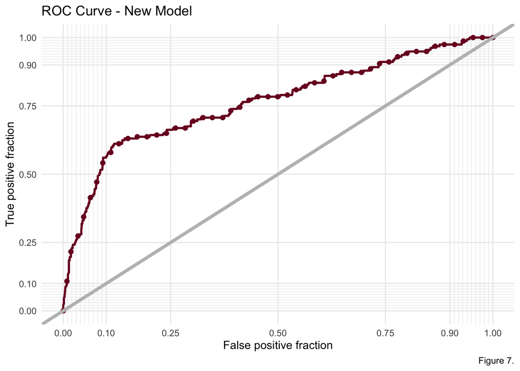

```r
ggplot(testProbs, aes(d = as.numeric(testProbs$Outcome), m = Probs)) +
  geom_roc(n.cuts = 50, labels = FALSE, colour = "#7a0728") +
  style_roc(theme = theme_grey) +
  geom_abline(slope = 1, intercept = 0, size = 1.5, color = 'grey') +
  labs(title = "ROC Curve - New Model",
       caption = "Figure 7.") +
  theme_minimal()
```

```r
# AUC
mod_AUC <- pROC::auc(testProbs$Outcome, testProbs$Probs) #0.7976
```

### Cost Benefit Analysis

Now, we perform a cost benefit analysis for our model. As a reminder, the HCD will allocate an average of $2,850 per homeowner for marketing, phone calls, counseling sessions etc. as a way to persuade the homeowner to enroll in the credit program. Out of the homeowners who join the program, we estimate that 25% of them end up taking the $5,000 credit. For each homeowner who takes the credit sees an average of a $10,000 premium on their house sale and an average neighborhood aggregate premium of $56,000 for homes surrounding the one that received the home repair credit.

This means that for each person that we predict would enroll in the program that does actually enroll (true positives, TP), we initially allocate an average of $2,850. Out of these homeowners, 25% will take the tax credit. Let’s say we correctly predicted $x$ homeowners to enroll, then the cost for TP would be $\$2,850 x + \$5,000x\times0.25 = \$4,100x$. On the other hand, for each homeowner we correctly predict to enroll in the program, 25% would take the credit and see an average $10,000 premium on their house sale and a $56,000 premium for neighboring houses, so the benefit would be $0.25x(\$10,000+\$56,000) = \$16,500x$. Thus, the total revenue for each TP would be $\$16,500x - \$4,100x = \$12,400$.

In the case that we correctly predicted that the homeowner would not enroll in the program (true negatives, TN), no money would be allocated for the marketing of the program and we would see no benefit from this either (assuming that all the TN wouldn’t take the tax credit). Therefore, the total revenue for each TN would be $0.

If we incorrectly predicted that a homeowner would enroll in the program (false positive, FP), we would initially allocate $2,850 for each person. No tax credit is allocated for these homeowners and we do not see any of the premiums we previously talked about on their house sales. Therefore with a $0 benefit, we see an overall revenue of -$2,850 for each FP.

Lastly, for all of the homeowners that we incorrectly predicted would not enroll in the program (false negatives, FN), we would not allocate any money, so this would cost us $0. Though they end up enrolling in the program, they enrolled due to reasons unrelated to the marketing campaign, so we assume that the benefit from these homeowners is also $0, resulting in a total revenue of $0.

```r
# table describing what TP, TN, FP, FN mean along with count and revenue
cost_benefit_table <-
   testProbs %>%
      count(predOutcome, Outcome) %>%
      summarize(`True Negative` = sum(n[predOutcome==0 & Outcome==0]),
                `True Positive` = sum(n[predOutcome==1 & Outcome==1]),
                `False Negative` = sum(n[predOutcome==0 & Outcome==1]),
                `False Positive` = sum(n[predOutcome==1 & Outcome==0])) %>%
       gather(Variable, Count) %>%
       mutate(Revenue =
               case_when(Variable == "True Negative"  ~ 0,
                         Variable == "True Positive"  ~ (-2850*Count + .25*(-5000+66000)*Count),
                         Variable == "False Negative" ~ 0,
                         Variable == "False Positive" ~ -2850*Count)) %>%
    bind_cols(data.frame(Description = c(
              "We predicted no program enrollment and the homeowner did not enroll",
              "We predicted program enrollment and the homeowner enrolled",
              "We predicted no program enrollment but the homeowner did enroll",
              "We predicted program enrollment, but homeowner did not enroll")))

cost_benefit_table %>%
  kbl(caption = "Table 2. Cost/Benefit Table for New Model") %>%
  kable_styling("striped", full_width = F) %>%
  kable_classic(full_width = F, html_font = "Cambria")
```

Table 2. Cost/Benefit Table for New Model

| Variable | Count | Revenue | Description |
| --- | --- | --- | --- |
| True Negative | 1238 | 0 | We predicted no program enrollment and the homeowner did not enroll |
| True Positive | 43 | 533200 | We predicted program enrollment and the homeowner enrolled |
| False Negative | 114 | 0 | We predicted no program enrollment but the homeowner did enroll |
| False Positive | 44 | -125400 | We predicted program enrollment, but homeowner did not enroll |

A unique aspect of using a logistic model is that we predict our outcome differently depending on how we set the threshold. Fiigure 8 visualizes the cost-benefit analysis by looking at the revenue by confusion matrix type for each 0.01 increment increase in threshold value. When we set the threshold to be vrey close to zero, we see about $2,000,000 in revenue from the TP, but at the same time we would be losing about $4,000,000 due to the FP. At first glance, it looks like the optimum threshold level is between 0.13-0.37.

```r
caret::confusionMatrix(testProbs$predOutcome, testProbs$Outcome,
                       positive = "1")

whichThreshold <-
  iterateThresholds(
     data=testProbs, observedClass = Outcome, predictedProbs = Probs)
```